# Business Analysis - Ford GoBike System

## Investigation Overview

This data set includes information about individual rides made in a bike-sharing system covering the greater San Francisco Bay area. I'm most interested in figuring out what features are best for predicting the business revenue and asset(bike) depreciation by referring to the duration time and distance. In addition, I am also interested in finding marketing points that are likely to improve efficiency and effectiveness in the business. I expect the type of users will have the most potent effect on duration and distance because subscribers are more likely to use the bike than customers along long stretches. I also think this will be variable depending on the day of the week.

## Dataset Overview

There are 183,412 unique bike_Id numbers in the dataset with 21 features (`duration_sec`, `start_time`, `end_time`, `start_station_id`, `start_station_name`, `start_station_latitude`, `start_station_longitude`, `end_station_id`, `end_station_name`, `end_station_latitude`, `end_station_longitude`, `bike_id, user_type`, `member_birth_year`, `member_gender`, `bike_share_for_all_trip`, `check_in_hour, date`, `day_of_week`, `distance_km`, and, `ReturnPoint`). Most variables are numeric in nature, but the variables `user_type`, `member_gender`, `bike_share_for_all_trip`, `check_in_hour`, `day_of_week`, `ReturnPoint`, `member_birth_year` are categorical variables with the following levels.

- user_type: Subscriber, Customer
- member_gender: Male, Female (or vice versa)
- bike_share_for_all_trip: Yes, No
- check_in_hour: 0 ~ 23
- day_of_week: 0(Mon) ~ 6(Sun)
- member_birth_year: 1878 ~ 2001(Year)
- ReturnPoint: 0(km), 0 ~ 1(km), 1 ~ 2(km), 2 ~ 3(km), 3 ~ 4(km), 4 ~ 5(km), 5 ~(km)

Note) `member_birth_year` and `day_of_week` are also applied both variables for investigation purposes.

## Executive summary

Most of the stations are located in three densely populated zones around San Francisco Bay. I assume that the primary purpose of using the bike is commuting from home to the office or neighborhood shopping, which is not just for exercise.

Make this Notebook Trusted to load map: File -> Trust Notebook

[interactive chart not shown]

```
< Top 10 Station Address >


Market St at 10th St                                         3904
San Francisco Caltrain Station 2  (Townsend St at 4th St)    3544
Berry St at 4th St                                           3052
Montgomery St BART Station (Market St at 2nd St)             2895
Powell St BART Station (Market St at 4th St)                 2760
San Francisco Ferry Building (Harry Bridges Plaza)           2710
San Francisco Caltrain (Townsend St at 4th St)               2703
Powell St BART Station (Market St at 5th St)                 2327
Howard St at Beale St                                        2293
Steuart St at Market St                                      2283
Name: start_station_name, dtype: int64
```

## Distribution of Duration (minute)

Duration forms almost standard distribution, where the average time is about 12.1 minutes. This could possibly mean that my initial assumption on the purpose of use is correct.

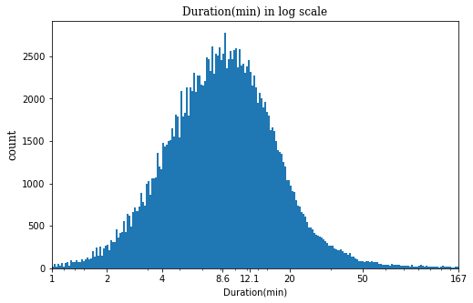

## Distribution of Distance (km)

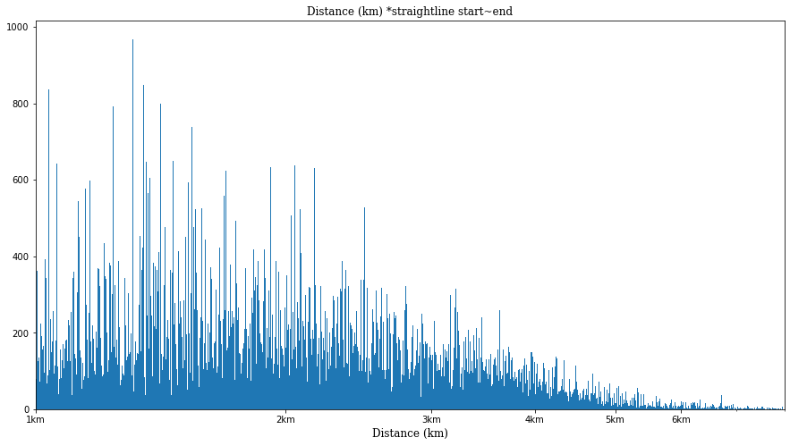

## Distribution of End-station

Most users park the bike where 1 to 2 kilometers away from the initial station. About 2.1% of checked-in users did not use the bike.

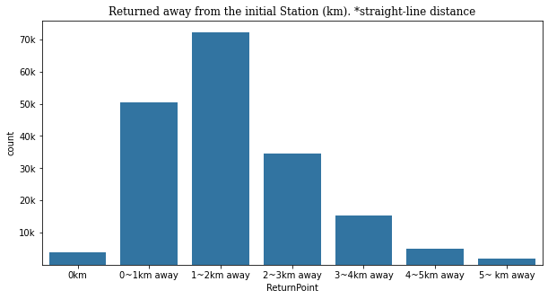

## Distribution of other variables

Subscribers are almost eight times as many as non-subscribers, and those are mostly male who is not sharing the bike during their entire trip.

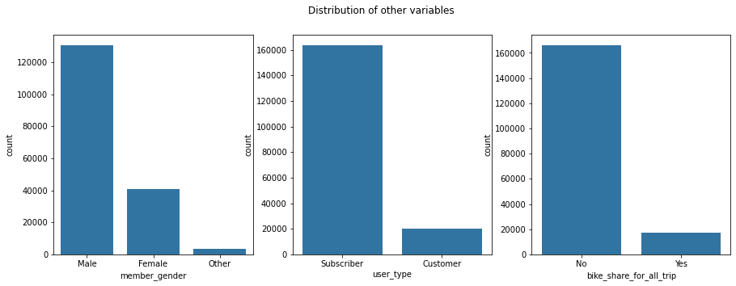

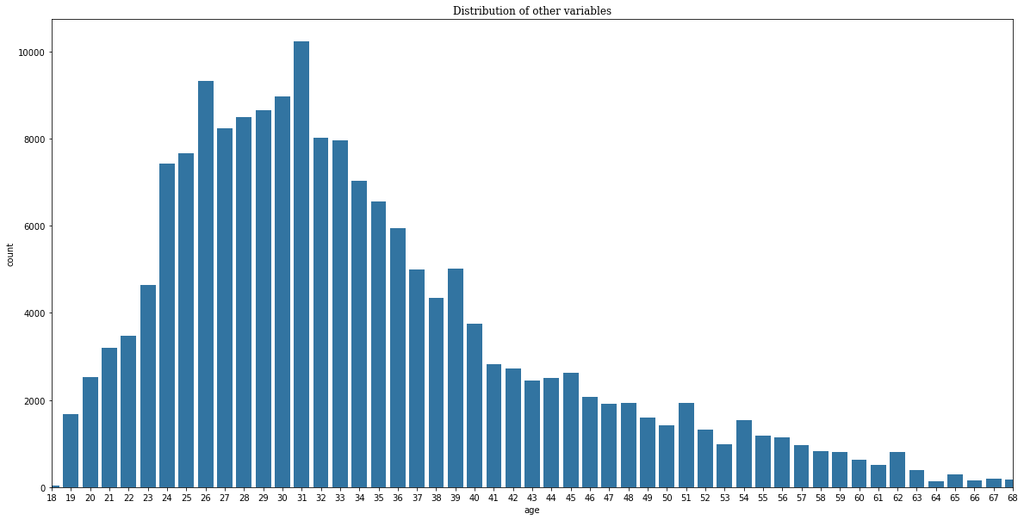

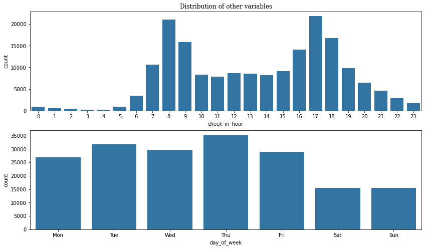

Most users used the bike during commuting hours regardless of gender, user types, bike-sharing, and weekdays. However, users checked in around noon during the weekends.

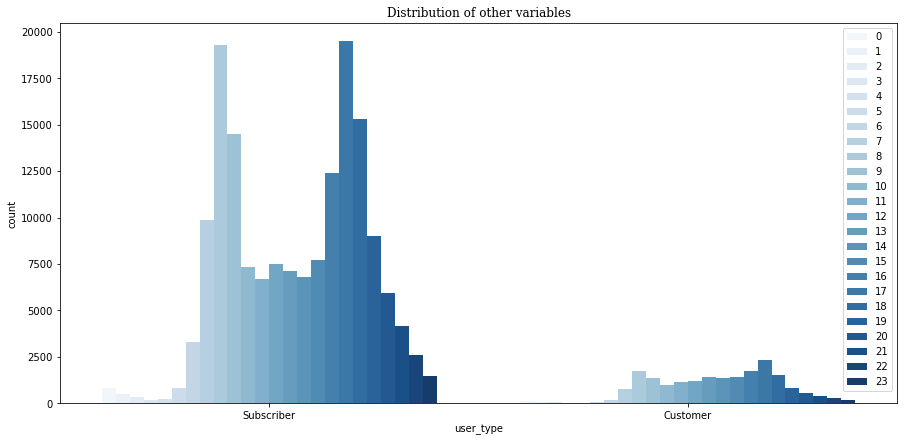

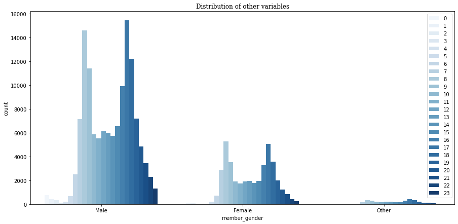

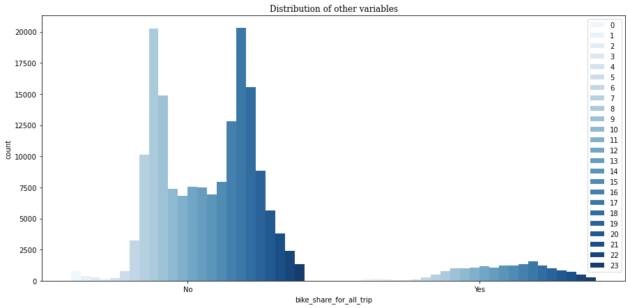

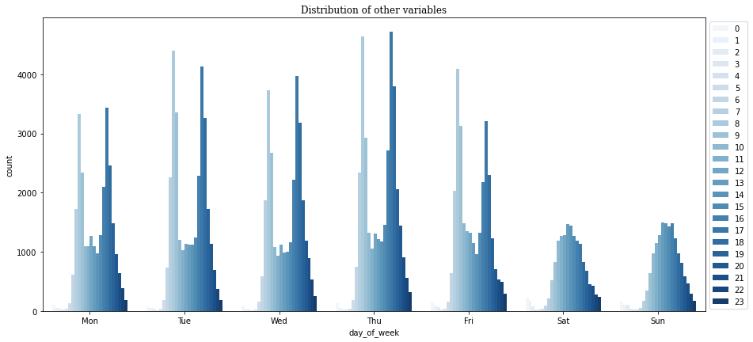

The younger the users are, the more diverse duration of use exists, and we can also find that the distance is not proportional to the duration, which provides evidence that only because the duration is long, it does not necessarily require that we need to increase this into the depreciation factor.

## Duration vs User type, Day of week, and Check in hour

Interestingly, the subscribers less used the bike than non-subscribers, which is probably a vital marketing point because we can increase the profit margin, revenue minus cost, with the membership contract. Although we figured out there are fewer users during the weekends, but they used more time. With these findings, we possibly recommend last-In bikes(high-tier inventory) to first-Out(serve) to weekend users with premium memberships.

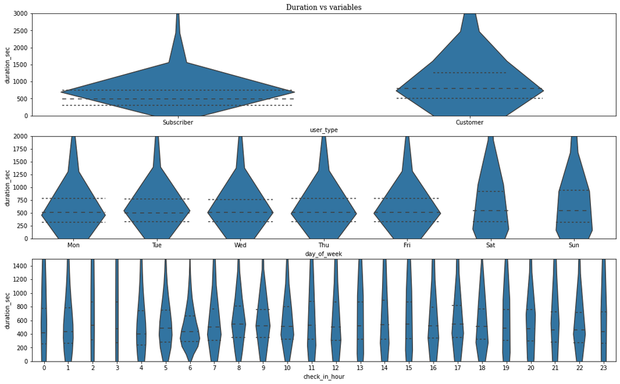

As we predicted, most subscribers used the bike during the weekdays.

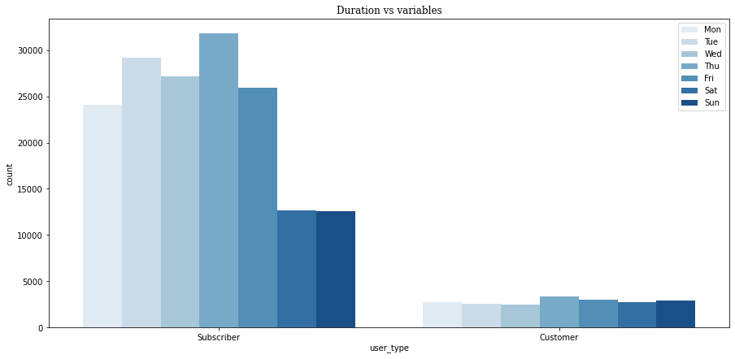

## Distance vs User type, Check in hour, and Bike share during the entire trip

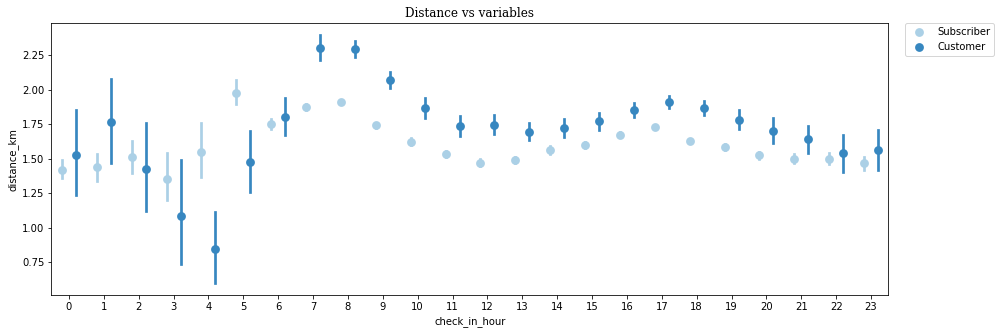

## Distance and Duration vs Member Birth Year

The duration per member's birth year forms a normal distribution to the 8.6-minute point; however, the distance plot is skewed to the left. This possibly explains that the age group between mid-'20s and mid-'30s are remarkable active users.

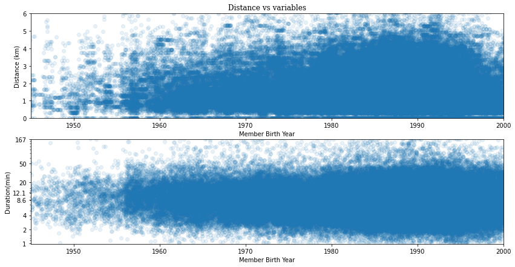

## Additional understandings

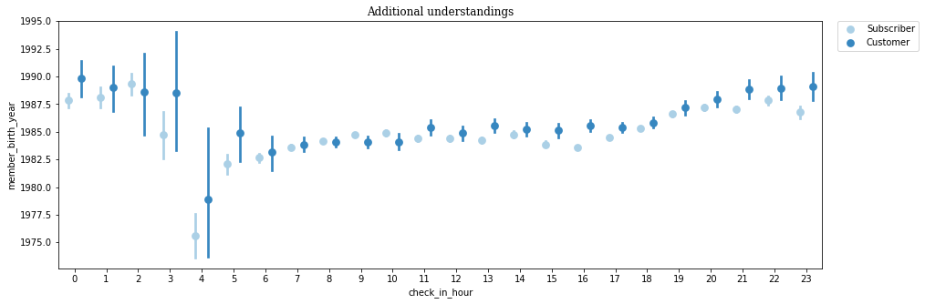

It is most difficult to predict for users who checked in between 2 a.m. and 4 a.m. how long the users will use bikes and how far away they will check out; however, they are primarily non-subscribing mixed-genders.

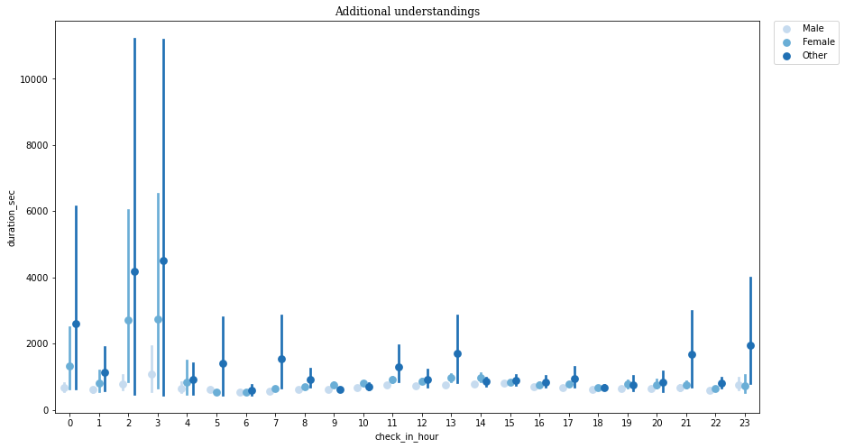

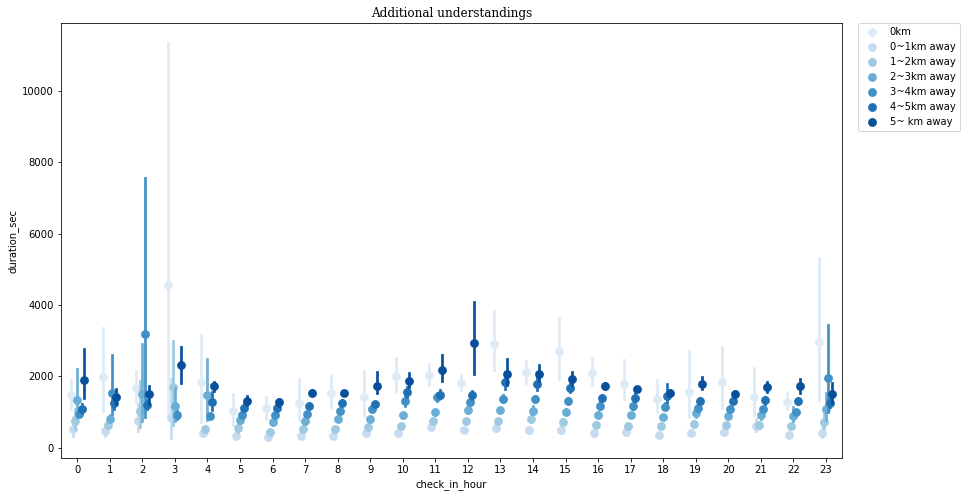

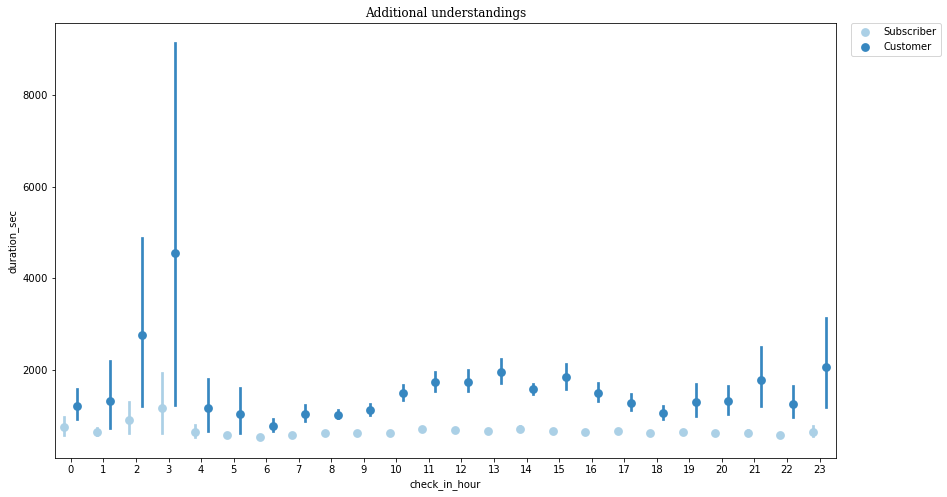

## Recommedation

The subscribers less used the bike than non-subscribers, which is probably a vital marketing point because we can increase the profit margin, revenue minus cost, with the membership contract. Although we figured out there are fewer users during the weekends, but they used more time. With these findings, we possibly recommend last-In bikes(high-tier inventory) to first-Out(serve) to weekend users with premium memberships.